# Random Sampling and Monte Carlo Estimators

Adam T’Koy

```r
knitr::opts_chunk$set(echo = TRUE)
set.seed(0000)
```

### Random Sampling: Acceptance-Rejection Method

Consider a random variable X with probability density $f_x(x) = \frac{1}{3} + \frac{1}{8}x^2$, $0 < x < 2$

To conduct acceptance-rejection sampling from $f_x(x)$, I choose g(y) to be the uniform distribution between 0 and 2: U(0,2).The support of g(y) is [0,2] which includes the support of f(x). This distribution is also continuous on the interval (0,2) and the PDF is given by 1 / (2 - 0), so g(y) = 1/2.

To estimate the acceptance rate, I need to find the upper bound of $\frac{f(t)}{g(t)}$, where $\frac{f(t)}{g(t)} = \frac{(\frac{1}{3} + \frac{1}{8} x^2)}{\frac{1}{2}} = \frac{2}{3} + \frac{1}{4} x^2$

Since this is a strictly positive function over the given interval, f(x) will be maximized when x is largest. Since x must be < 2, the upper bound of f(x) is f(2) = 5/3 = c.

This means I should expect the acceptance rate to be approximately $\frac{1}{c} = \frac{3}{5}$ or 60%.

I will draw 1750 samples from U(0,2) and keep the first 1000 accepted:

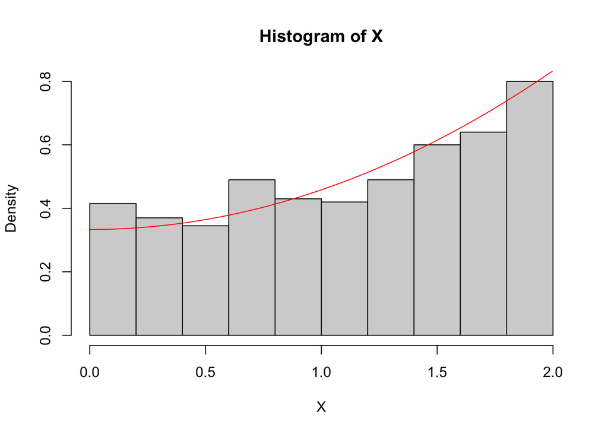

```r
Y <- runif(1750, 0, 2)    # 1750 draws from U(0,2)
c <- 5/3
U <- runif(1750)          # 1750 draws from U(0,1)

accept <- U < (((1/3) + (1/8)*Y^2) / (c * 0.5))

X <- (Y[accept])[1:1000]

hist(X, freq = F, ylim=c(0,0.8))

xx <- seq(0,2,.01)
fx <- (1/3) + (1/8) * xx^2
lines(xx, fx, type = 'l', col='red')
```

X can also be regarded as a mixture of two distribution: $f_x(x) = \frac{2}{3} f_1(x) + \frac{1}{3} f_2(x)$, $0 < x < 2$, where $f_1(x)$ is the U(0,2) density, and $f_2(x) = \frac{3}{8}x^2$.

So I can generate samples of X by generating samples from the mixture distribution.

Integrating $f_2(t)$ from 0 to x gives me a CDF of: $\frac{x^3}{8}$ Then the inverse of the CDF is: $2 \cdot \sqrt[3]{x}$

```r
# Function to compute inverse of f2(x)
f2x <- function(x) {
  2 * x^(1/3)
}
```

Now I can use the Transformation Method to obtain the desired samples.

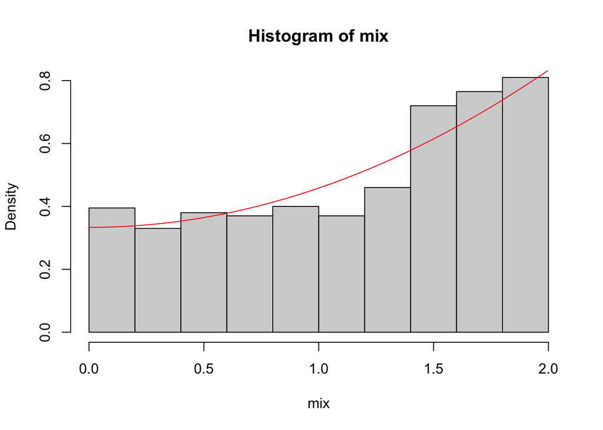

```r
# f1(x): U(0,2)
X_f1x <- runif(1000, 0, 2)

# f2(x): transformation
U_f2x <- runif(1000)
X_f2x <- f2x(U_f2x)

u <- runif(1000)
k <- as.integer(u < 2/3)

mix <- (k * X_f1x) + ((1-k) * X_f2x)

# Histogram of Empirical Density
hist(mix, prob=TRUE, ylim=c(0,0.8))

# Theoretical Density Curve
xxd <- seq(0,2,.01)
fxd <- (2/3)*(1/2) + (1/3) * (3/8) * xxd^2
lines(xxd, fxd, type = 'l', col='red')
```

### Random Sampling: Transformation Method

Suppose $Y_1, Y_2$ are independent, and $Y_1 \sim X^2(m), Y_2 \sim X^2(n)$. Then $X = \frac{Y_1/m}{Y_2/n} \sim F(m,n)$ (X follows the F distribution with m and n degrees of freedom).

We can again apply the Transformation Method to draws easily obtained from the standard normal distribution to obtain samples from the F(3,50) distribution.

```r
m <- 3
n <- 50

Y1 <- rowSums(matrix(rnorm(1000*m), 1000, m)^2)    # chi-squared 3df

Y2 <- rowSums(matrix(rnorm(1000*n), 1000, n)^2)    # chi-squared 50df

F_3_50 <- (Y1 / m) / (Y2 / n)
```

We can also use these samples together with the F(3,50) density as the importance function to obtain a Monte Carlo estimate of $p = P(X \geq 2) = E_x[I(X \geq 2)] = \int_{0}^{\infty} I(X \geq 2) f_x(x) dx$.

```r
a <- 2
greater_than_equal_a <- 1*(F_3_50 >= a)
mean(greater_than_equal_a)
```

```
## [1] 0.136
```

```r
# For comparison: R's built-in probability density function ('pf')
1 - pf(2, df1 = 3, df2 = 50)
```

```
## [1] 0.1259421
```

### Monte Carlo Estimation

We will use Monte Carlo integration to estimate $\theta = erf(\sqrt{2}) = \int_{0}^{\sqrt{2}} \frac{2}{\sqrt{\pi}} e^{-t^2} dt$, as well as obtain a point estimate and a 95% confidence interval for $\theta$.

```r
X_3a <- runif(1000, 0, sqrt(2))
gX_3a <- (2 / sqrt(pi)) * exp(-(X_3a)^2)
theta_hat_3a <- (sqrt(2) - 0) * mean(gX_3a)
theta_hat_3a
```

```
## [1] 0.9603417
```

```r
# Variance
v = mean((gX_3a - mean(gX_3a))^2) / 1000

# 95% Confidence Interval
c(theta_hat_3a - qnorm(0.975) * sqrt(v), theta_hat_3a + qnorm(0.975) * sqrt(v))
```

```
## [1] 0.9403277 0.9803556
```

Next we’ll use stratified sampling for $\theta$ with a total sample size of 1000 and 4 equal-width, equal-size strata.

```r
strat_mc <- function(total_num, num_strat) {
  xjs <- seq(0, sqrt(2), length.out = num_strat + 1)
  theta = 0

  for (j in 1:num_strat) {
    X <- runif(total_num/num_strat, min=xjs[j], max=xjs[j+1])
    gx <- (2/sqrt(pi)) * exp(-X^2)
    theta = theta + (sqrt(2)/num_strat) * mean(gx)
  }
  return (theta)
}

strat_mc(1000,4)
```

```
## [1] 0.9628246
```

Next is importance sampling for $\theta$ using the standard normal PDF on $(-\infty, \infty)$ as the importance function and 1000 samples.

```r
# 1000 standard normal samples
norm_draws <- rnorm(1000)

# Only count samples between -2 and +2
between <- 1*(norm_draws > -2 & norm_draws < 2)

# Mean is our estimate
mean(between)
```

```
## [1] 0.96
```

```r
# Comparing against R's built-in 'pnorm' function
pnorm(2) - pnorm(-2)
```

```
## [1] 0.9544997
```

```r
MC_reps <- matrix(NA, 100, 3)

# Simple MC
for(rep in 1:100) {
  X <- runif(1000, 0, sqrt(2))
  gX <- (2 / sqrt(pi)) * exp(-(X)^2)
  MC_reps[rep,1] <- sqrt(2) * mean(gX)
}

# Stratified MC
for(rep in 1:100) {
  MC_reps[rep,2] <- strat_mc(1000,4)
}

# Importance Sampling MC (Standard Normal Draws)
for(rep in 1:100) {
  norm_draws <- rnorm(1000)
  between <- 1*(norm_draws > -2 & norm_draws < 2)
  MC_reps[rep,3] <- mean(between)
}

round(apply(MC_reps, 2, sd), 6)
```

```
## [1] 0.014005 0.003022 0.006273
```

According to these results, the Simple Monte Carlo estimator is the least efficient, then the standard normal draws, and the stratified MC estimator is the most efficient.

### Applying the Transformation Method to Estimate a Maximum

An airline operates a flight with a capacity of 100 seats. Each seat is sold at $100. Historical data suggests approximately 10% of ticket holders do not show up for the flight. Assume that for $n$ tickets sold, the number of passengers that show, $X$, follows a Binomial distribution: $X \sim Binomial(n, p = .9)$

To maximize revenue, the airline considers overbooking the flight. However, if more passengers show up than there are seats available, the airline faces the cost of compensating bumped passengers. Assume the compensation cost for each bumped passenger is $200.

Suppose the airline sells $n = 110$ tickets. Let Y = max{X - 100, 0} denote the number of bumped passengers. Using the transformation method, we will draw 1000 samples of Y and plot the histogram of its empirical distribution.

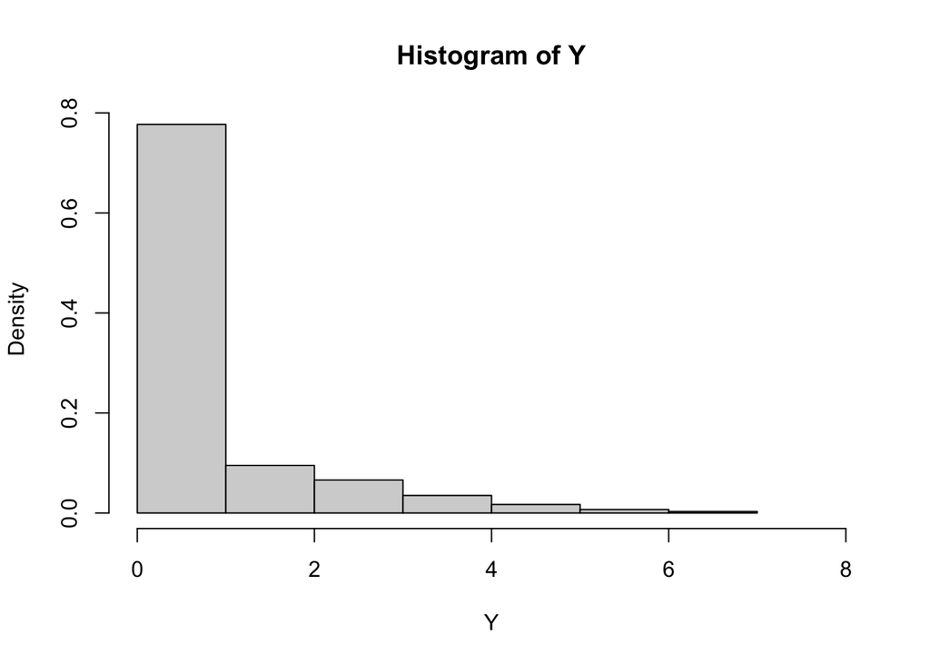

```r
X <- rbinom(1000, size=110, prob=0.9)
Y <- pmax(X - 100, 0)
hist(Y, freq=F, xlim=c(0,8), breaks=8)
```

The expected revenue is given by $E_Y(100n - 200Y)$. Using the 1000 samples from above, we can estimate the expected revenue for $n = 110$ tickets:

```r
mean(100 * 110 - 200 * Y)
```

```
## [1] 10842.8
```

We can also use this information to find the number of tickets that the airline should sell in order to maximize revenue:

```r
tests <- c()

for(rep in 100:120) {
  X <- rbinom(1000, size=rep, prob=0.9)
  Y <- pmax(X - 100, 0)
  tests[rep-99] <- mean(100 * rep - 200 * Y)
}

# All expected revenues for 100 to 120 tickets sold
tests
```

```
##  [1] 10000.0 10100.0 10200.0 10300.0 10398.4 10494.8 10589.6 10671.0 10741.8
## [10] 10805.2 10834.6 10855.4 10850.0 10825.6 10805.6 10745.2 10695.8 10611.2
## [19] 10557.8 10486.0 10380.2
```

```r
# Maximum revenue amount
max(tests)
```

```
## [1] 10855.4
```

According to these results, the airline should sell 111 tickets to maximize expected revenue.